**Projekt zaliczeniowy z przedmiotu**

**Metody walidacji modeli statystycznych**

**Bartosz Oleszek**

2025-06-09

## **Wybór zbioru danych**

W projekcie wykorzystano zbiór danych **Bank Customer Churn Prediction**, dostępny publicznie na platformie Kaggle: https://www.kaggle.com/datasets/gauravtopre/bank-customer-churn-dataset

Zbiór ten zawiera informacje o klientach banku, które mogą być pomocne w analizie zachowań konsumenckich, w szczególności w kontekście rezygnacji z usług bankowych. Dane są gotowe do użycia i nadają się do budowy i badania modeli uczenia maszynowego.

Zbiór danych obejmuje:

- 10 000 obserwacji,
- 12 zmiennych, w tym dane demograficzne, finansowe oraz informację o tym, czy klient opuścił bank (zmienna `churn`).

| customer_id | credit_score | country | gender | age | tenure | balance | products_number | credit_card | active_member | estimated_salary | churn |
| --- | --- | --- | --- | --- | --- | --- | --- | --- | --- | --- | --- |
| 15634602 | 619 | France | Female | 42 | 2 | 0.00 | 1 | 1 | 1 | 101348.88 | 1 |
| 15647311 | 608 | Spain | Female | 41 | 1 | 83807.86 | 1 | 0 | 1 | 112542.58 | 0 |
| 15619304 | 502 | France | Female | 42 | 8 | 159660.80 | 3 | 1 | 0 | 113931.57 | 1 |
| 15701354 | 699 | France | Female | 39 | 1 | 0.00 | 2 | 0 | 0 | 93826.63 | 0 |
| 15737888 | 850 | Spain | Female | 43 | 2 | 125510.82 | 1 | 1 | 1 | 79084.10 | 0 |
| 15574012 | 645 | Spain | Male | 44 | 8 | 113755.78 | 2 | 1 | 0 | 149756.71 | 1 |

## **Zdefiniowanie problemu predykcyjnego oraz scharakteryzowanie analizowanego zbioru danych**

Celem projektu jest zbudowanie i porównanie różnych modeli klasyfikacyjnych w celu znalezienia najlepszego rozwiązania do **przewidywania odejścia klienta z banku** na podstawie jego cech demograficznych i finansowych.

Zmienna docelowa `churn` wskazuje, czy klient zrezygnował z usług bankowych:

- `0` – klient pozostał w banku,
- `1` – klient odszedł.

Problem ten ma charakter **binarny (klasyfikacja 0/1)** i jest istotny z perspektywy biznesowej, ponieważ umożliwia budowanie systemów wczesnego ostrzegania o możliwej utracie klienta (Customer Retention Systems).

### **Niezbalansowanie klas**

Rozkład liczby obserwacji w poszczególnych klasach jest nierównomierny:

| Klasa | Opis | Liczba obserwacji | Procent (%) |
| --- | --- | --- | --- |
| 0 | klient pozostał | 7963 | 79.6 |
| 1 | klient odszedł | 2037 | 20.4 |

Taka struktura danych sugeruje potrzebę zastosowania odpowiednich technik balansowania danych treningowych (np. undersampling klasy dominującej lub oversampling klasy mniejszościowej) w celu poprawy skuteczności modeli predykcyjnych.

### **Opis zmiennych w zbiorze danych**

#### **1. Dane demograficzne**

- `customer_id` – unikalny identyfikator klienta
- `country` – kraj pochodzenia klienta (`France`, `Germany`, `Spain`)
- `gender` – płeć klienta (`Male`, `Female`)
- `age` – wiek klienta

#### **2. Dane dotyczące relacji z bankiem**

- `tenure` – liczba lat współpracy z bankiem
- `products_number` – liczba produktów bankowych posiadanych przez klienta
- `credit_card` – informacja, czy klient posiada kartę kredytową (0 = nie, 1 = tak)
- `active_member` – czy klient jest aktywnym użytkownikiem usług banku (0/1)

#### **3. Dane finansowe**

- `credit_score` – ocena zdolności kredytowej klienta (skala punktowa - wyższa wartość oznacza większą wiarygodność kredytową)
- `balance` – saldo na koncie klienta
- `estimated_salary` – szacowane wynagrodzenie klienta

#### **4. Zmienna docelowa**

- `churn` – informacja, czy klient zrezygnował z usług bankowych (0 = nie, 1 = tak)

## **Czyszczenie danych oraz wstępna selekcja cech**

### **Sprawdzenie braków danych występujących w zbiorze**

```r
any(colSums(is.na(df)) != "0")
```

```
## [1] FALSE
```

Zwrócona wartość `FALSE` oznacza, że wszystkie kolumny są kompletne i nie wymagają imputacji braków.

### **Usunięcie identyfikatora klienta**

Zmienna `customer_id` jest unikalnym identyfikatorem klienta i nie wnosi wartości predykcyjnej do modelu.

```r
df <- df %>% dplyr::select(-customer_id)
```

### **Podział na zbiór treningowy, walidacyjny i testowy**

Aby uniknąć przecieku danych i zapewnić obiektywną ocenę modeli, dane zostały podzielone na zbiór treningowy (70%), walidacyjny (15%) i testowy (15%). Podział został wykonany losowo, z zachowaniem proporcji klas zmiennej docelowej `churn`.

```r
set.seed(333)
initial_split <- initial_split(df, prop = 0.85, strata = churn)
dev_data <- training(initial_split)
test_data <- testing(initial_split)


dev_split <- initial_split(dev_data, prop = 70/85, strata = churn)
train_data <- training(dev_split)
valid_data <- testing(dev_split)
```

Dalsze przetwarzanie danych, selekcja cech, balansowanie oraz trenowanie modeli będzie wykonywane wyłącznie na zbiorze treningowym `train_data` oraz walidacyjnym`valid_data`. Zbiór testowy `test_data` zostanie wykorzystany wyłącznie do końcowej oceny skuteczności wybranych modeli.

### **Konwersja na odpowiednie typy zmiennych**

Zmienne kategoryczne przekształcono do typu factor, co jest wymagane w większości modeli klasyfikacyjnych.

```r
factor_vars <- c(
  "country", "gender", "credit_card", "active_member", "churn", "products_number"
)

train_data[factor_vars] <- lapply(train_data[factor_vars], as.factor)
valid_data[factor_vars] <- lapply(valid_data[factor_vars], as.factor)
test_data[factor_vars] <- lapply(test_data[factor_vars], as.factor)
```

### **Usunięcie zmiennych o niskiej zmienności**

W kolejnym kroku sprawdzono, czy w zbiorze treningowym występują zmienne o bardzo niskiej wariancji – zarówno numeryczne (wariancja bliska zeru), jak i kategoryczne (zdominowane przez jedną wartość). Takie zmienne nie wnoszą informacji do modelu i mogą wprowadzać szum.

```r
num_data <- train_data %>% dplyr::select(where(is.numeric))
cat_data <- train_data %>% dplyr::select(where(is.factor))

low_var_num <- sapply(num_data, var, na.rm = TRUE)
low_var_num_cols <- names(low_var_num[low_var_num < 1e-5])

low_var_cat_cols <- cat_data %>%
  summarise(across(everything(), ~ max(table(.) / sum(!is.na(.))))) %>%
  pivot_longer(cols = everything(), names_to = "variable", values_to = "max_prop") %>%
  filter(max_prop > 0.95) %>%
  pull(variable)

low_variance_cols <- c(low_var_num_cols, low_var_cat_cols)

train_data <- train_data %>% dplyr::select(-all_of(low_variance_cols))
valid_data <- valid_data %>% dplyr::select(-all_of(low_variance_cols))
test_data  <- test_data %>% dplyr::select(-all_of(low_variance_cols))

low_variance_cols
```

```
## character(0)
```

Nie wykryto żadnych zmiennych o zbyt niskiej wariancji, więc struktura danych nie została zmieniona.

### **Analiza korelacji pomiędzy zmiennymi numerycznymi**

W celu wykrycia potencjalnych redundancji lub współliniowości, przeanalizowano korelacje pomiędzy wszystkimi zmiennymi numerycznymi w zbiorze treningowym.

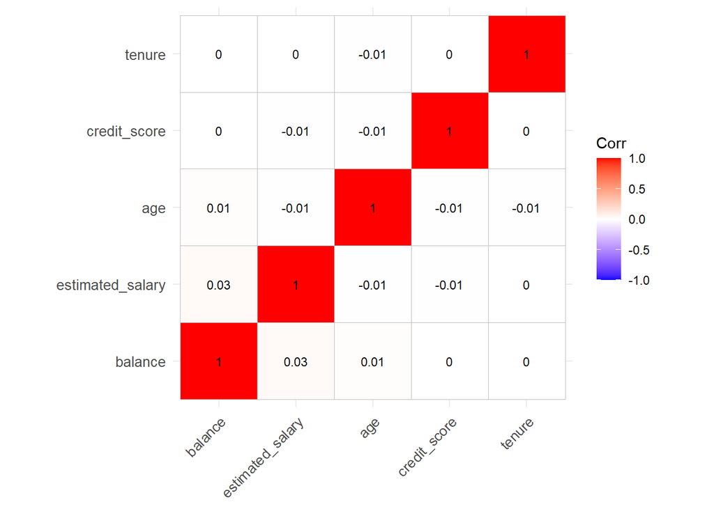

```r
correlation_data <- train_data %>% dplyr::select(where(is.numeric))

cor_results <- rcorr(as.matrix(correlation_data))
cor_matrix <- cor_results$r
p_matrix <- cor_results$P

ggcorrplot(
  cor_matrix,
  hc.order = TRUE,
  type = "full",
  lab = TRUE,
  show.legend = TRUE,
  tl.cex = 10,
  lab_size = 3,
  colors = c("blue", "white", "red")
)
```

Na podstawie analizy można stwierdzić, że korelacje pomiędzy zmiennymi numerycznymi są bardzo niskie. Współczynniki korelacji Pearsona mieszczą się w przedziale od –0.01 do 0.03, co oznacza, że **brakuje istotnej współliniowości** między zmiennymi. Żadna z analizowanych cech nie wykazuje wyraźnej redundancji względem innych, dlatego wszystkie mogą zostać uwzględnione w dalszym modelowaniu bez obawy o współliniowość.

### **Analiza istotności cech na podstawie Mutual Information**

W celu oceny istotności predyktorów względem zmiennej docelowej `churn`, zastosowano miarę **Mutual Information**. Uwzględnia ona zarówno zależności liniowe, jak i nieliniowe, dzięki czemu lepiej odzwierciedla relacje między zmiennymi niż klasyczna korelacja. Poniżej przedstawiono uporządkowaną tabelę wyników oraz odpowiadający jej wykres łokciowy, który pozwala wizualnie ocenić, które cechy wnoszą najwięcej informacji.

```r
# zamiana factorów na character (wymóg FSelectorRcpp)
df_mi <- train_data %>%
  mutate_if(is.factor, as.character)

# obliczenie mutual information względem zmiennej churn
mi_scores <- information_gain(churn ~ ., data = df_mi)

mi_sorted <- mi_scores %>% arrange(desc(importance))

mi_table <- tibble(
  Zmienna = mi_sorted$attributes,
  `Mutual Information` = number(mi_sorted$importance, accuracy = 0.0001)
)

mi_table %>%
  kbl() %>%
  kable_styling(bootstrap_options = c("striped", "hover"), full_width = FALSE)
```

| Zmienna | Mutual Information |
| --- | --- |
| products_number | 0.0711 |
| age | 0.0669 |
| country | 0.0135 |
| active_member | 0.0124 |
| balance | 0.0076 |
| gender | 0.0061 |
| credit_score | 0.0034 |
| credit_card | 0.0000 |
| tenure | 0.0000 |
| estimated_salary | 0.0000 |

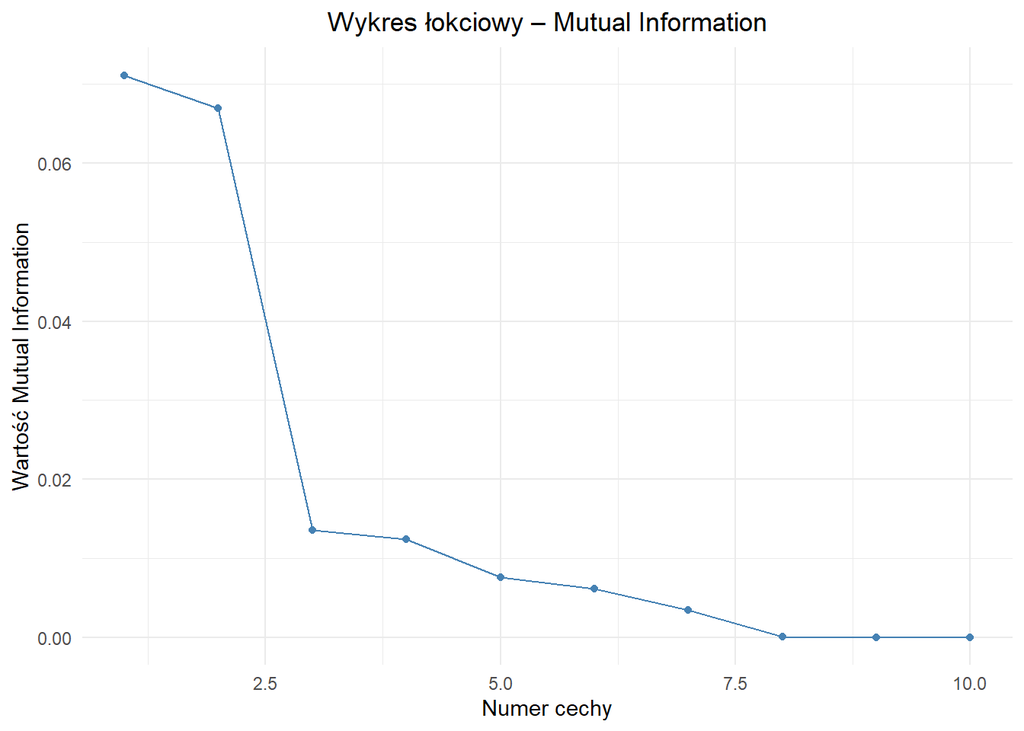

```r
mi_sorted <- mi_scores %>%
  arrange(desc(importance))

mi_sorted_plot <- mi_sorted %>%
  mutate(index = row_number())

ggplot(mi_sorted_plot, aes(x = index, y = importance)) +
  geom_line(color = "steelblue") +
  geom_point(color = "steelblue") +
  labs(
    title = "Wykres łokciowy – Mutual Information",
    x = "Numer cechy",
    y = "Wartość Mutual Information"
  ) +
  theme_minimal() +
  theme(plot.title = element_text(hjust = 0.5))
```

Na podstawie uzyskanych wyników Mutual Information oraz wykresu łokciowego można zauważyć wyraźny spadek wartości informacyjnej po pierwszych dwóch cechach `products_number` i `age`. Ich wartości MI wynoszą odpowiednio 0.0711 i 0.0669, co oznacza, że mają one istotny wpływ na wartość zmiennej zależnej.

Wartość Mutual Information dla kolejnych cech spada gwałtownie (poniżej 0.015), co wskazuje na ich znacznie mniejszy wkład w przewidywanie zmiennej `churn`. Z tego względu, jako najbardziej istotne predyktory do dalszego modelowania można rozważyć:

- wybór tylko dwóch najistotniejszych zmiennych `age` i `products_number`,
- uwzględnienie dodatkowo cech `country` i `active_member`, które również przekraczają próg 0.01.

Dla większej pewności zostanie teraz zastosowana **alternatywna selekcja cech z użyciem metody Boruta**, w celu porównania wyników i potwierdzenia znaczenia wybranych predyktorów.

### **Analiza istotności cech z użyciem metody Boruta**

W celu potwierdzenia wyników selekcji uzyskanych metodą Mutual Information zastosowano również algorytm **Boruta**, który opiera się na modelu lasu losowego i ocenia istotność predyktorów na podstawie porównania ich wpływu z wpływem sztucznie wygenerowanych „cech losowych”

```r
df_boruta <- train_data %>%
  mutate_if(is.factor, as.character)

df_boruta$churn <- as.factor(df_boruta$churn)

boruta_path <- "boruta_results.rds"

if (file.exists(boruta_path)) {
  boruta_result <- readRDS(boruta_path)
} else {
  set.seed(123)
  boruta_result <- Boruta(churn ~ ., data = df_boruta, doTrace = 1)
  saveRDS(boruta_result, boruta_path)
}
confirmed_vars <- getSelectedAttributes(boruta_result, withTentative = FALSE)
cat("Istotnymi zmiennymi wg metody Boruta są:", paste(confirmed_vars, collapse = ", "))
```

```
## Istotnymi zmiennymi wg metody Boruta są: credit_score, country, gender, age, balance, products_number, active_member
```

Analiza wykazała, że **7 zmiennych zostało uznanych za istotne**: `active_member`, `age`, `balance`, `country`, `credit_score`, `gender` oraz `products_number`.

Metoda Boruta potwierdziła wysoką istotność czterech zmiennych wskazanych wcześniej przez Mutual Information: `products_number`, `age`, `active_member`, `country`, a także dodatkowo zasugerowała możliwą wartość predykcyjną kolejnych trzech zmiennych.

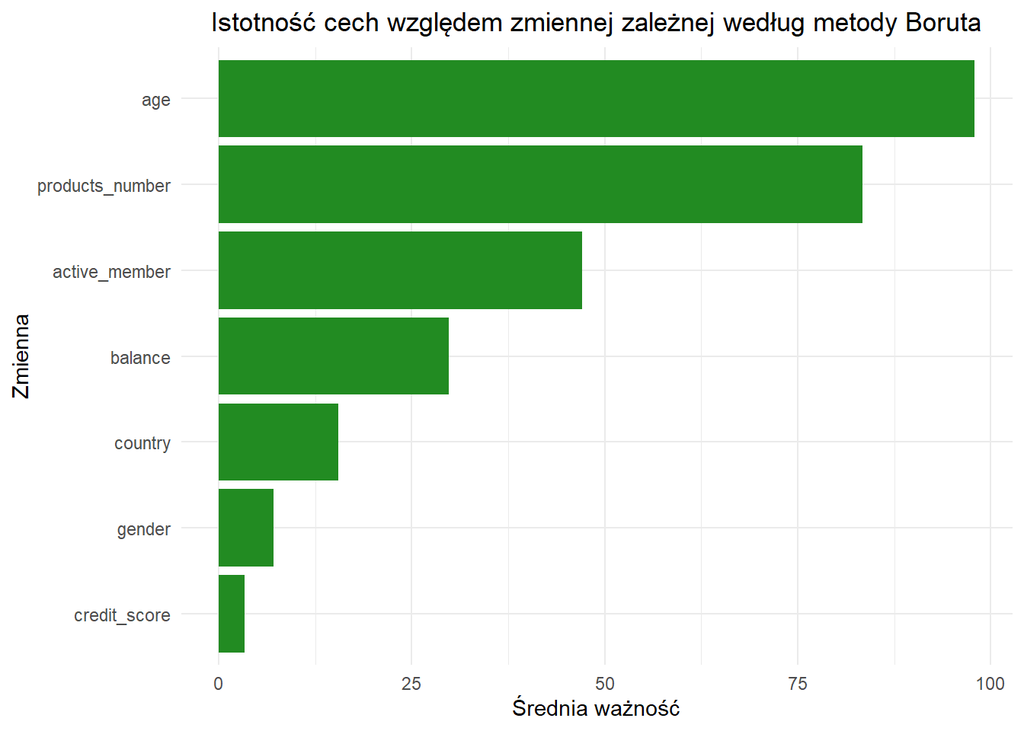

```r
importance_df <- attStats(boruta_result) %>%
  rownames_to_column("Zmienna") %>%
  filter(decision != "Rejected")

ggplot(importance_df, aes(x = reorder(Zmienna, meanImp), y = meanImp, fill = decision)) +
  geom_col(show.legend = FALSE) +
  coord_flip() +
  labs(
    title = "Istotność cech względem zmiennej zależnej według metody Boruta",
    x = "Zmienna",
    y = "Średnia ważność"
  ) +
  scale_fill_manual(values = c("Confirmed" = "forestgreen", "Tentative" = "gold")) +
  theme_minimal() +
  theme(plot.title = element_text(hjust = 0.5))
```

W kolejnej sekcji zostaną szczegółowo przeanalizowane wszystkie zmienne wskazane przez Borutę. Dla każdej z nich zostanie sprawdzona zależność pomiędzy wartością zmiennej a klasą `churn`, w celu określenia, czy większy sens ma trenowanie modeli na ograniczonym zestawie 4 predyktorów, czy też na pełnym zestawie 7 cech uznanych za istotne.

## **Omówienie oraz zwizualizowanie istotnych zależności w analizowanym zbiorze danych**

### **1. Porównanie wartości cech numerycznych w zależności od statusu churn**

Na poniższym wykresie przedstawiono rozkład trzech wybranych zmiennych numerycznych w podziale na status klienta `churn`. Wstępna analiza boxplotów pozwala wysunąć następujące przypuszczenia:

- wiek `age`: klienci, którzy odeszli z banku `churn` = 1, wydają się być średnio starsi niż ci, którzy pozostali `churn` = 0.
- saldo konta `balance`: W grupie `churn` = 1 mediana salda jest wyższa niż w grupie `churn` = 0. Można przypuszczać istnienie różnic między grupami.
- ocena kredytowa `credit_score`: Rozkłady wyglądają na zbliżone w obu grupach, bez wyraźnych różnic w medianie. Trudno oczekiwać istotnej zależności od statusu klienta.

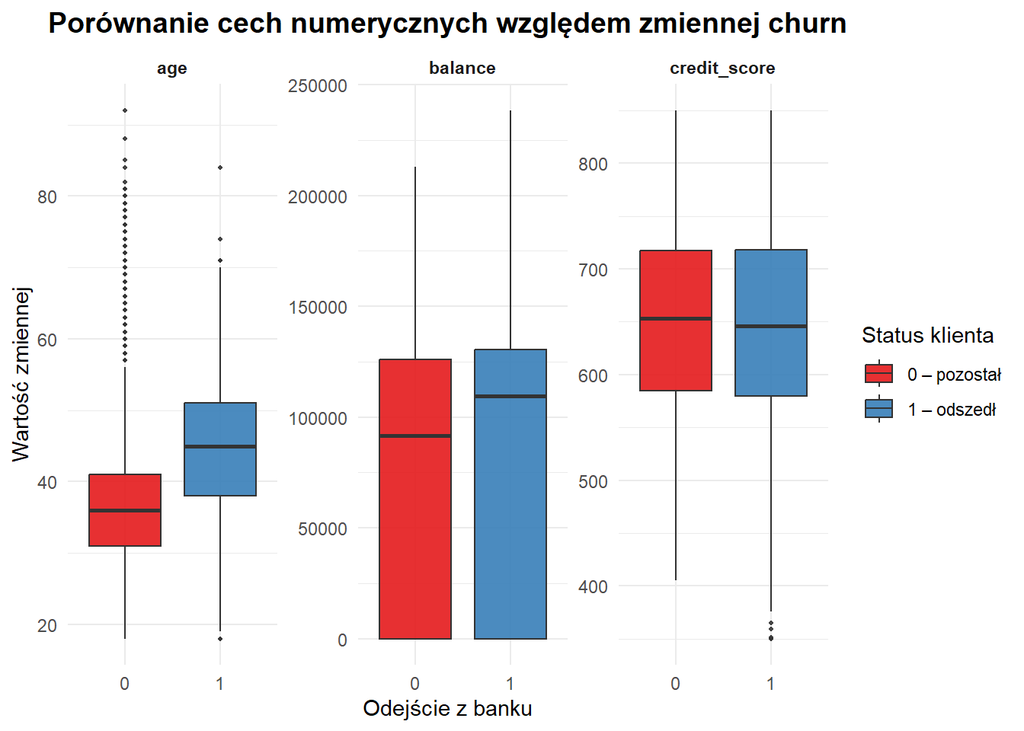

Na podstawie powyższej wizualizacji można przypuszczać, że zmienne `age` oraz `balance` mogą istotnie różnicować grupy klientów względem zmiennej zależnej `churn`. W celu weryfikacji tych obserwacji, w kolejnym kroku przeprowadzone zostaną testy statystyczne. Aby dobrać odpowiedni test (parametryczny lub nieparametryczny), konieczne jest uprzednie sprawdzenie założeń dotyczących normalności rozkładów.

#### **Sprawdzenie normalności rozkładów**

```
## Zmienne: age | churn = 0 | p-value = 3.7e-24
## Zmienne: age | churn = 1 | p-value = 0.04464292
## Zmienne: balance | churn = 0 | p-value = 3.7e-24
## Zmienne: balance | churn = 1 | p-value = 3.7e-24
## Zmienne: credit_score | churn = 0 | p-value = 3.398149e-08
## Zmienne: credit_score | churn = 1 | p-value = 0.03869157
```

Dla każdej z analizowanych zmiennych numerycznych przeprowadzono test normalności Andersona–Darlinga osobno w grupach `churn` = 0 i `churn` = 1. We wszystkich przypadkach uzyskano wartości p<0.05, co oznacza, że rozkłady badanych zmiennych nie są zgodne z rozkładem normalnym. W związku z tym, do porównania zmiennych pomiędzy grupami zastosowano nieparametryczny test U Manna–Whitneya, który nie wymaga założenia o normalności.

```r
vars <- c("age", "balance", "credit_score")

for (v in vars) {
  test_result <- wilcox.test(train_data[[v]] ~ train_data$churn)
  cat("Zmienne:", v, "| p-value =", round(test_result$p.value, 5), "\n")
}
```

```
## Zmienne: age | p-value = 0
## Zmienne: balance | p-value = 0
## Zmienne: credit_score | p-value = 0.15425
```

Test Manna-Whitneya wykazał, że zmienne `age` oraz `balance` różnicują istotnie grupy klientów względem zmiennej `churn` (p < 0.05), dlatego zostaną uwzględnione w dalszym modelowaniu. Dla zmiennej `credit_score` uzyskano p > 0.05, co oznacza brak istotnych różnic między grupami - w związku z tym cecha ta nie będzie brana pod uwagę w kolejnych etapach analizy.

### **2. Analiza cech kategorycznych względem zmiennej churn**

Na wykresach przedstawiono liczebności klientów, którzy odeszli `churn` = 1 i którzy pozostali `churn` = 0 w poszczególnych grupach zmiennych kategorycznych.

Widać wyraźnie, że:

- w grupie nieaktywnych klientów `active_member` = 0 odsetek rezygnacji jest zauważalnie wyższy niż wśród aktywnych,
- w przypadku kraju pochodzenia `country`, wśród klientów z Niemiec proporcja `churn` jest znacznie wyższa niż np. we Francji,
- dla płci `gender` różnice są mniej wyraźne, ale nadal zauważalne – więcej rezygnujących klientów to kobiety,
- w przypadku liczby produktów `products_number`, najwięcej odejść występuje wśród klientów z 1 produktem – to może sugerować słabsze zaangażowanie w ofertę banku.

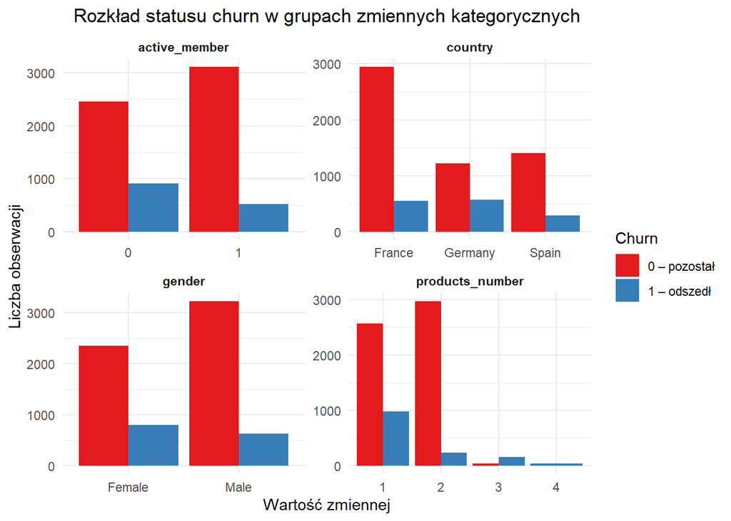

Na podstawie przedstawionych wizualizacji można przypuszczać, że analizowane zmienne kategoryczne są związane ze statusem klienta `churn` i mogą mieć istotną wartość predykcyjną. Aby potwierdzić te obserwacje, przeprowadzone zostaną testy niezależności chi-kwadrat Pearsona.

```
##
## ========== gender ==========
## Chi² test p-value: 2.145656e-20
##
## ========== active_member ==========
## Chi² test p-value: 3.362907e-39
##
## ========== country ==========
## Chi² test p-value: 1.113521e-44
##
## ========== products_number ==========
## Chi² test p-value: 2.382467e-231
```

Dla wszystkich analizowanych zmiennych kategorycznych uzyskano bardzo niską wartość p (p<0.05), co oznacza, że zmienne te mają istotny wpływ na odejście klienta z banku i mogą być wykorzystywane jako predyktory w dalszym modelowaniu.

### **Ostateczny wniosek - wybór cech do modelowania**

Na podstawie przeprowadzonych testów statystycznych wybrano finalny zestaw istotnych predyktorów do budowy modeli klasyfikacyjnych:

- zmienne numeryczne: `age`, `balance`
- zmienne kategoryczne: `gender`, `active_member`, `country`, `products_number`

Zmienne te zostaną wykorzystane w kolejnym etapie procesu analitycznego – przygotowaniu danych do modelowania oraz trenowaniu i walidacji modeli predykcyjnych.

```r
selected_vars <- c("churn", "age", "balance", "gender", "active_member", "country", "products_number")

train_data <- train_data %>% dplyr::select(all_of(selected_vars))
valid_data <- valid_data %>% dplyr::select(all_of(selected_vars))
test_data  <- test_data %>% dplyr::select(all_of(selected_vars))
```

## **Przygotowanie danych do dalszego procesu modelowania i ich eksploracja z użyciem technik uczenia maszynowego**

### **Ustawienie klasy pozytywnej (klient odszedł) jako `1`**

Dla łatwiejszej interpretacji ustawiono klasę pozytywną jako `1`, czyli klient odszedł z banku. Uporządkowanie poziomów klas w ten sposób ułatwia analizę metryk (np. recall i precision będą dotyczyć właśnie klasy odchodzących).

```r
train_data$churn <- factor(train_data$churn, levels = c("1", "0"))
valid_data$churn <- factor(valid_data$churn, levels = c("1", "0"))
test_data$churn  <- factor(test_data$churn,  levels = c("1", "0"))
```

### **Stworzenie recipe dla SMOTE**

```r
recipe_smote <- recipe(churn ~ ., data = train_data) %>%
  step_normalize(all_numeric_predictors()) %>%
  step_dummy(all_nominal_predictors()) %>%
  step_smote(churn, seed = 333)
```

### **Definicja listy modeli do przetestowania**

Utworzono listę pięciu klasyfikatorów, które zostaną porównane. Każdy model zostaje skonfigurowany do trybu klasyfikacji `classification` i przypisany do odpowiedniego silnika `engine`.

```r
set.seed(333)
model_list <- list(
  logistic = logistic_reg() %>% set_engine("glm") %>% set_mode("classification"),
  random_forest = rand_forest() %>% set_engine("ranger") %>% set_mode("classification"),
  svm = svm_rbf() %>% set_engine("kernlab") %>% set_mode("classification"),
  xgboost = boost_tree() %>% set_engine("xgboost") %>% set_mode("classification"),
  naive_bayes = naive_Bayes() %>% set_engine("klaR") %>% set_mode("classification")
)
```

### **Tworzenie workflowów - połączenie modeli z recipe**

Utworzono funkcję pomocniczą, która łączy wybrany model z przepisem `recipe` w jedną strukturę workflow. Następnie tworzone są workflowy dla wszystkich modeli z listy, wykorzystując `recipe_smote`.

```r
create_workflow <- function(model_spec, recipe_obj) {
  workflow() %>%
    add_model(model_spec) %>%
    add_recipe(recipe_obj)
}
```

```r
workflow_list <- purrr::map(model_list, create_workflow, recipe_obj = recipe_smote)
names(workflow_list) <- names(model_list)
```

### **Funkcja do trenowania modeli i obliczania metryk**

Funkcja ta dopasowuje workflow do danych treningowych, wykonuje predykcję na zbiorze treningowym i walidacyjnym, oblicza wybrane metryki (accuracy, precision, recall, F1) oraz generuje macierz pomyłek (confusion matrix).

```r
evaluate_workflow <- function(wf, train_data, valid_data) {

  set.seed(333)
  chosen_metrics <- metric_set(accuracy, precision, recall, f_meas)

  # dopasowanie modelu
  fitted_wf <- fit(wf, data = train_data)

  # predykcje na zbiorze treningowym
  train_class <- predict(fitted_wf, new_data = train_data)
  train_probs <- predict(fitted_wf, new_data = train_data, type = "prob")
  train_preds <- bind_cols(train_data, train_class, train_probs)
  # predykcje na zbiorze walidacyjnym
  valid_class <- predict(fitted_wf, new_data = valid_data)
  valid_probs <- predict(fitted_wf, new_data = valid_data, type = "prob")
  valid_preds <- bind_cols(valid_data, valid_class, valid_probs)

  train_metrics <- chosen_metrics(train_preds, truth = churn, estimate = .pred_class)
  valid_metrics <- chosen_metrics(valid_preds, truth = churn, estimate = .pred_class)

  # macierz pomyłek
  valid_cm <- conf_mat(valid_preds, truth = churn, estimate = .pred_class)

  return(list(
    model = fitted_wf,
    train_metrics = train_metrics,
    valid_metrics = valid_metrics,
    valid_conf_mat = valid_cm
  ))
}
```

### **Trenowanie wszystkich modeli i zebranie wyników**

Wywołano wyżej zdefiniowaną funkcję dla każdego modelu, używając tego samego zbioru treningowego i walidacyjnego. Zwrócone zostają metryki i macierze pomyłek dla każdego modelu.

```r
set.seed(333)
evaluation_results <- purrr::map(workflow_list, evaluate_workflow,
                                 train_data = train_data,
                                 valid_data = valid_data)
names(evaluation_results) <- names(workflow_list)
```

### **Przedstawienie metryk dla każdego z modelu**

Utworzono funkcję `get_metrics_df()`, która pobiera metryki trenowania lub walidacji z listy wyników modeli. Następnie zostaną wygenerowane tabele metryk osobno dla zbioru treningowego i walidacyjnego.

```r
set.seed(333)
get_metrics_df <- function(results_list, dataset = "train") {
  purrr::map_dfr(results_list,
                 ~ .x[[paste0(dataset, "_metrics")]],
                 .id = "model")
}

train_metrics_all <- get_metrics_df(evaluation_results, dataset = "train")
valid_metrics_all <- get_metrics_df(evaluation_results, dataset = "valid")
```

### **Łączenie metryk i przygotowanie do wizualizacji**

Dodajemy oznaczenie pochodzenia zbioru `train` lub `valid`, łączymy wyniki, usuwamy niepotrzebne kolumny i przekształcamy dane do formatu szerokiego (dzięki temu nie wyświetla nam sie ten sam model w kilku liniach), co ułatwia porównanie modeli.

```r
set.seed(333)
train_metrics_all <- train_metrics_all %>% mutate(dataset = "train")
valid_metrics_all <- valid_metrics_all %>% mutate(dataset = "valid")

all_metrics <- bind_rows(train_metrics_all, valid_metrics_all) %>%
  dplyr::select(-.estimator)

metrics_wide <- all_metrics %>%
  pivot_wider(names_from = .metric, values_from = .estimate) %>%
  arrange(model, dataset)
```

### **Tabela wyników dla omawianych modeli po balansowaniu SMOTE**

| model | dataset | accuracy | precision | recall | f_meas |
| --- | --- | --- | --- | --- | --- |
| logistic | train | 0.763 | 0.450 | 0.754 | 0.564 |
| logistic | valid | 0.757 | 0.442 | 0.735 | 0.552 |
| naive_bayes | train | 0.646 | 0.350 | 0.867 | 0.499 |
| naive_bayes | valid | 0.647 | 0.353 | 0.876 | 0.503 |
| random_forest | train | 0.875 | 0.658 | 0.806 | 0.724 |
| random_forest | valid | 0.825 | 0.559 | 0.686 | 0.616 |
| svm | train | 0.803 | 0.511 | 0.764 | 0.613 |
| svm | valid | 0.793 | 0.496 | 0.722 | 0.588 |
| xgboost | train | 0.833 | 0.566 | 0.763 | 0.650 |
| xgboost | valid | 0.824 | 0.554 | 0.709 | 0.622 |

### **Wniosek:**

Spośród wszystkich przetestowanych modeli najlepszy rezultat na zbiorze walidacyjnym osiągnął model **XGBoost**, uzyskując najwyższą wartość F1-score = 0.622. Oznacza to, że model ten najlepiej równoważy czułość (recall = 0.709) oraz precyzję (precision = 0.554) – czyli skutecznie wykrywa klientów, którzy odchodzą z banku, jednocześnie minimalizując liczbę fałszywych alarmów.

Dodatkowo, wartości metryk uzyskanych na zbiorze treningowym (F1-score = 0.650, recall = 0.763, precision = 0.566) są zbliżone do wyników na zbiorze walidacyjnym. Taka spójność świadczy o tym, że model nie jest przeuczony, a jego ogólna zdolność do generalizacji na nowych danych jest bardzo dobra.

Na podstawie powyższych analiz można uznać, że **XGBoost jest najbardziej zrównoważonym i skutecznym modelem do przewidywania odejścia klientów z banku w ramach tego projektu**.

### **Macierz pomyłek dla modelu XGBoost po balansowaniu SMOTE**

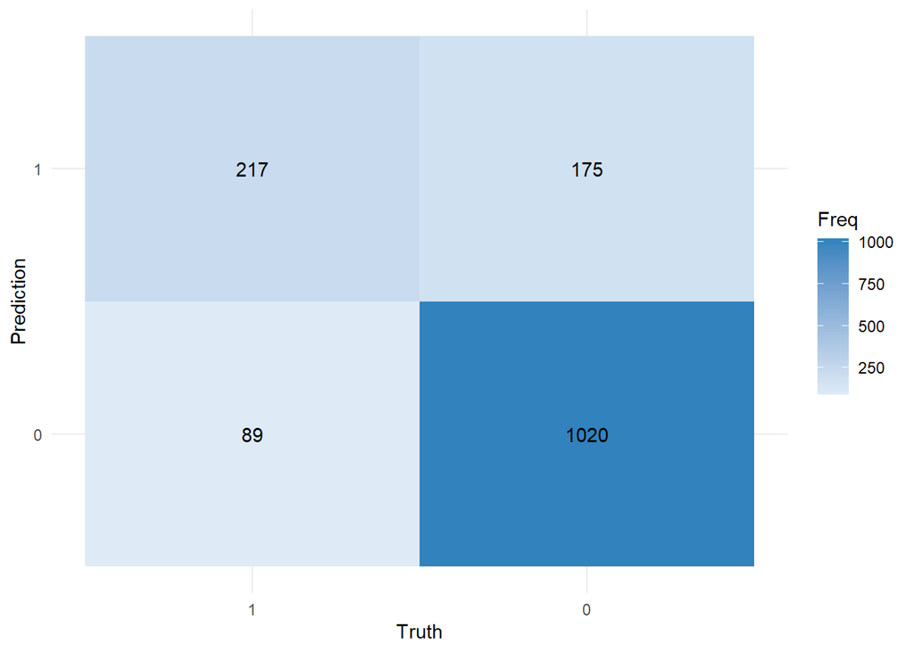

Model wykrył 217 rzeczywistych odejść i błędnie przewidział odejście w 175 przypadkach. Jednocześnie przegapił 89 odejść i poprawnie przewidział, że 1020 klientów nie odejdzie. Takie rozłożenie błędów wskazuje, że model ma solidne podstawy i potencjał do dalszej poprawy. Przy zastosowaniu odpowiedniej metody balansowania danych oraz optymalizacji hiperparametrów, możliwe jest jeszcze skuteczniejsze wykrywanie klientów skłonnych do odejścia.

**W kolejnym etapie porównane zostaną różne metody balansowania danych zastosowane na zbiorze treningowym. Celem jest wybór takiej techniki, która – w połączeniu z modelem XGBoost – zapewni najlepsze wyniki predykcyjne na zbiorze walidacyjnym.**

## **Porównanie metod balansowania danych**

W tej części zostanie porównane pięć technik balansowania danych przy stałym modelu XGBoost:

- Brak balansowania (baseline),
- SMOTE (Synthetic Minority Oversampling Technique),
- ROSE (Random Over-Sampling Examples),
- Oversampling (losowe powielanie klasy mniejszościowej),
- Undersampling (losowe usuwanie z klasy większościowej).

Dla każdej metody utworzono osobny `recipe`, który różni się jedynie zastosowaną techniką balansowania. Następnie na ich podstawie zbudowano workflowy z wykorzystaniem tego samego modelu bazowego (XGBoost). Do oceny skuteczności zastosowano wcześniej zdefiniowaną funkcję `evaluate_workflow()`.

```r
# Kod tworzenia recipe, workflowów oraz oceny został pominięty
# ponieważ struktura i przebieg są analogiczne do poprzedniego etapu.
```

Następnie każdy model oceniono na zbiorze walidacyjnym przy użyciu tych samych metryk: F1-score, recall, precision oraz accuracy.

### **Tabela porównawcza – skuteczność metod balansowania**

| balancing | dataset | accuracy | precision | recall | f_meas |
| --- | --- | --- | --- | --- | --- |
| downsample | train | 0.804 | 0.511 | 0.822 | 0.631 |
| downsample | valid | 0.779 | 0.474 | 0.748 | 0.580 |
| none | train | 0.876 | 0.821 | 0.498 | 0.620 |
| none | valid | 0.855 | 0.760 | 0.425 | 0.545 |
| rose | train | 0.204 | 0.204 | 1.000 | 0.338 |
| rose | valid | 0.204 | 0.204 | 1.000 | 0.339 |
| smote | train | 0.833 | 0.566 | 0.763 | 0.650 |
| smote | valid | 0.824 | 0.554 | 0.709 | 0.622 |
| upsample | train | 0.832 | 0.560 | 0.818 | 0.665 |
| upsample | valid | 0.811 | 0.527 | 0.742 | 0.616 |

W celu poprawy skuteczności wykrywania klientów odchodzących z banku, porównano pięć metod balansowania danych zastosowanych na zbiorze treningowym: brak balansowania, **SMOTE**, **ROSE**, **oversampling** (upsample) oraz **undersampling** (downsample).

Wszystkie techniki zostały przetestowane w połączeniu z modelem **XGBoost** o domyślnych parametrach. Skuteczność oceniano na podstawie zbioru walidacyjnego, przy szczególnym uwzględnieniu metryk recall oraz F1-score, które są najważniejsze w kontekście detekcji klasy mniejszościowej (klientów odchodzących).

W początkowej analizie najlepsze wyniki uzyskano dla modelu XGBoost z zastosowaniem metody SMOTE, który osiągnął **F1-score = 0.622**, **recall = 0.709** i **precision = 0.554**. Metryki były stabilne między zbiorem treningowym a walidacyjnym, co świadczy o dobrej generalizacji.

W ramach porównania różnych technik balansowania (SMOTE, ROSE, oversampling, undersampling, brak balansowania), żadna z alternatywnych metod nie poprawiła wyników osiąganych przez SMOTE – tym samym potwierdzono zasadność jego wyboru jako optymalnej strategii dla modelu XGBoost.

### **Finalny wybór**

Zatem uznajemy, że model **XGBoost** najlepiej sobie radzi na zbiorze walidacyjnym, po balansowaniu metodą **SMOTE**.

Dla tego połączenia zajmiemy się teraz tuningiem parametrów tego modelu.

## **Ewaluacja modeli uczenia maszynowego oraz ich kalibracja**

W tym kroku skoncentrowano się na optymalizacji parametrów modelu XGBoost, aby poprawić skuteczność predykcji zmiennej `churn`. Zamiast używać domyślnych wartości, zdecydowano się na losowe przeszukiwanie przestrzeni hiperparametrów - metodę, która:

- pozwala szybciej znaleźć dobre rozwiązania w dużej przestrzeni możliwych ustawień,
- została uznana w literaturze za bardziej efektywną od siatek pełnych (`grid search`) – szczególnie przy wielu parametrach.

Tuning obejmuje 6 najważniejszych parametrów:

### **Definicja modelu XGBoost z tunowanymi parametrami**

```r
xgboost_tune_spec <- boost_tree(
  trees = tune(),
  tree_depth = tune(),
  learn_rate = tune(),
  loss_reduction = tune(),
  sample_size = tune(),
  mtry = tune()
) %>%
  set_engine("xgboost") %>%
  set_mode("classification")
```

### **Połączenie modelu z przepisem**

```r
workflow_xgb <- workflow() %>%
  add_model(xgboost_tune_spec) %>%
  add_recipe(recipe_smote)
```

### **Określenie przestrzeni hiperparametrów**

Zamiast domyślnych zakresów, zdefiniowano **rozsądne granice** dla każdego parametru, by przeszukiwanie było skuteczniejsze.

```r
set.seed(333)

xgb_params <- parameters(
  trees(range = c(300, 1500)),
  tree_depth(range = c(2, 10)),
  learn_rate(range = c(0.001, 0.3)),
  loss_reduction(range = c(0, 10)),
  sample_size = sample_prop(range = c(0.5, 1.0)),
  finalize(mtry(), train_data)
)
```

### **Generacja losowej siatki hiperparametrów**

Z przestrzeni określonej powyżej losujemy 75 zestawów parametrów. Taka liczba pozwala dobrze „zeskanować” przestrzeń bez nadmiernego kosztu obliczeniowego.

```r
set.seed(333)
xgb_grid <- grid_random(xgb_params, size = 75)
```

### **Przygotowanie walidacji krzyżowej**

W celu wiarygodnej oceny modeli zastosowano 5-krotną walidację krzyżową z utrzymaniem proporcji klas (`strata = churn`).

```r
set.seed(333)
folds <- vfold_cv(train_data, v = 5, strata = churn)
```

### **Trening i zapis wyników do pliku**

```r
cl <- makeCluster(5)
registerDoParallel(cl)

set.seed(333)
tuned_xgb <- tune_grid(
  workflow_xgb,
  resamples = folds,
  grid = xgb_grid,
  metrics = metric_set(f_meas, recall, precision, accuracy),
  control = control_grid(save_pred = TRUE)
)

stopCluster(cl)
registerDoSEQ()
saveRDS(tuned_xgb, file = "tuned_xgb_v2.rds")
```

#### **Wczytanie gotowego obiektu**

```r
tuned_xgb <- readRDS("tuned_xgb_v2.rds")
```

### **Wybór najlepszego zestawu hiperparametrów na podstawie ważonej funkcji metryk**

**Ustalona funkcja oceny modelu**

Po przeprowadzeniu tuningu i wygenerowaniu 75 losowych zestawów hiperparametrów, dla każdego z nich obliczono podstawowe metryki jakości modelu: `accuracy`, `precision`, `recall`, `F1-score`.

Zamiast polegać na jednej wybranej metryce, zdecydowano się na ocenę modeli na podstawie **ważonej funkcji wszystkich czterech wskaźników**, zgodnie z priorytetami problemu:

- największy nacisk położono na czułość (recall) – czyli zdolność wykrycia klientów odchodzących,
- następnie na ogólną równowagę błędów, czyli F1-score,
- w dalszej kolejności – na precyzję,
- i w najmniejszym stopniu na trafność ogólną (accuracy).

Wzór użyty do obliczenia ogólnego wyniku (`weighted_score`) dla każdego zestawu hiperparametrów był następujący:

$$\text{Wynik} = 0.4 \cdot \text{recall} + 0.3 \cdot \text{F1-score} + 0.2
\cdot \text{precision} + 0.1 \cdot \text{accuracy}$$

### **Obliczenie wartości weighted_score i wybór najlepszych modeli**

Na podstawie wyników walidacji krzyżowej (CV), metryki zostały przekształcone do formatu „szerokiego” – tak, aby każda kombinacja hiperparametrów odpowiadała jednej linii. Następnie dodano kolumnę `weighted_score`, a najlepsze 10 konfiguracji posortowano malejąco.

### **Top 10 zestawów wg weighted_score**

| mtry | trees | tree_depth | learn_rate | loss_reduction | sample_size | accuracy | f_meas | precision | recall | weighted_score |
| --- | --- | --- | --- | --- | --- | --- | --- | --- | --- | --- |
| 4 | 642 | 9 | 1.0072 | 54.3278 | 0.5824 | 0.8131 | 0.6050 | 0.5328 | 0.7011 | 0.6498 |
| 1 | 366 | 7 | 1.2204 | 97.1417 | 0.9035 | 0.7927 | 0.5875 | 0.4945 | 0.7249 | 0.6444 |
| 7 | 1428 | 6 | 1.2958 | 68.5443 | 0.5851 | 0.8015 | 0.5916 | 0.5095 | 0.7060 | 0.6419 |
| 2 | 610 | 4 | 1.2455 | 9.9436 | 0.8658 | 0.8355 | 0.6082 | 0.5909 | 0.6274 | 0.6352 |
| 1 | 1293 | 3 | 1.2380 | 10.2913 | 0.6579 | 0.8257 | 0.6004 | 0.5639 | 0.6428 | 0.6326 |
| 4 | 565 | 5 | 1.1911 | 197.3394 | 0.7881 | 0.7561 | 0.5527 | 0.4447 | 0.7382 | 0.6256 |
| 7 | 474 | 2 | 1.0151 | 1.9423 | 0.6329 | 0.8427 | 0.6014 | 0.6215 | 0.5832 | 0.6223 |
| 1 | 757 | 2 | 1.7528 | 2.1325 | 0.9633 | 0.8208 | 0.5823 | 0.5563 | 0.6126 | 0.6131 |
| 6 | 723 | 4 | 1.5201 | 189.7406 | 0.5066 | 0.7461 | 0.5211 | 0.4272 | 0.6765 | 0.5870 |
| 1 | 837 | 6 | 1.3481 | 3.2806 | 0.7821 | 0.8119 | 0.5559 | 0.5360 | 0.5782 | 0.5865 |

Spośród 75 przetestowanych konfiguracji, najwyższy wynik uzyskał zestaw z:

- `mtry` = 4
- `trees` = 642
- `tree_depth` = 9
- `learn_rate` = 1.0072
- `loss_reduction` = 54.3278
- `sample_size` = 0.5824

Ten model osiągnął:

- accuracy = 0.8131
- F1-score = 0.6050
- precision = 0.5328
- recall = 0.7011
- weighted_score = 0.6498

### **Przypisanie najlepszego zestawu parametrów do workflowa**

Na podstawie najwyższego `weighted_score`, utworzono nowy obiekt zawierający optymalne parametry:

```r
best_params <- tibble::tibble(
  mtry = 4,
  trees = 642,
  tree_depth = 9,
  learn_rate = 1.0072,
  loss_reduction = 54.3278,
  sample_size = 0.5824)
```

### **Zbudowanie workflowa i dopasowanie modelu na zbiorze treningowym i walidacyjnym**

```r
final_xgb_workflow <- finalize_workflow(workflow_xgb, best_params)
```

Po przypisaniu najlepszego zestawu hiperparametrów do workflowa, model został wytrenowany na zbiorze treningowym (`train_data`). Następnie dokonano predykcji zarówno na zbiorze treningowym, jak i walidacyjnym, aby porównać skuteczność predykcji i ocenić ryzyko przeuczenia.

```r
set.seed(333)

fitted_model <- fit(final_xgb_workflow, data = train_data)

preds_train <- predict(fitted_model, new_data = train_data) %>%
  bind_cols(train_data)

preds_valid <- predict(fitted_model, new_data = valid_data) %>%
  bind_cols(valid_data)
```

### **Obliczenie metryk dla zbioru treningowe i walidacyjnego po tuningu oraz porównanie wyników z modelem domyślnym**

Poniżej przedstawiono porównanie metryk dla modelu bazowego (XGBoost z domyślnymi parametrami + SMOTE) oraz modelu po tuningu, zarówno dla zbioru treningowego, jak i walidacyjnego:

| Model | Zbiór | Accuracy | Precision | Recall | F1-score |
| --- | --- | --- | --- | --- | --- |
| XGBoost default | train | 0.833 | 0.566 | 0.763 | 0.650 |
| XGBoost default | valid | 0.824 | 0.554 | 0.709 | 0.622 |
| Tuning XGBoost | train | 0.830 | 0.568 | 0.688 | 0.622 |
| Tuning XGBoost | valid | 0.819 | 0.546 | 0.654 | 0.595 |

### **Wniosek - porównanie modeli**

**2. Stabilność metryk** W modelu domyślnym różnica między train i valid dla F1-score wynosiła 0.028 (0.650 → 0.622), a w modelu po tuningu 0.027 (0.622 → 0.595). Różnice w recall spadły z 0.054 do 0.034.

**3. Koszt – złożoność vs skuteczność** Tuning pozwolił dobrać bardziej zrównoważoną konfigurację, która prawdopodobnie jest mniej agresywna (mniejsze recall, ale większa stabilność), co może być korzystne w praktycznych zastosowaniach, gdzie liczy się przewidywalność i powtarzalność.

Model po tuningu nieznacznie ustępuje bazowemu pod względem recall, ale cechuje się lepszą równowagą pomiędzy zbiorami i mniejszą różnicą metryk – dzięki czemu **można go uznać za bardziej stabilny i mniej podatny na przeuczenie**.

### **Macierz pomyłek – zbiór walidacyjny (model po tuningu)**

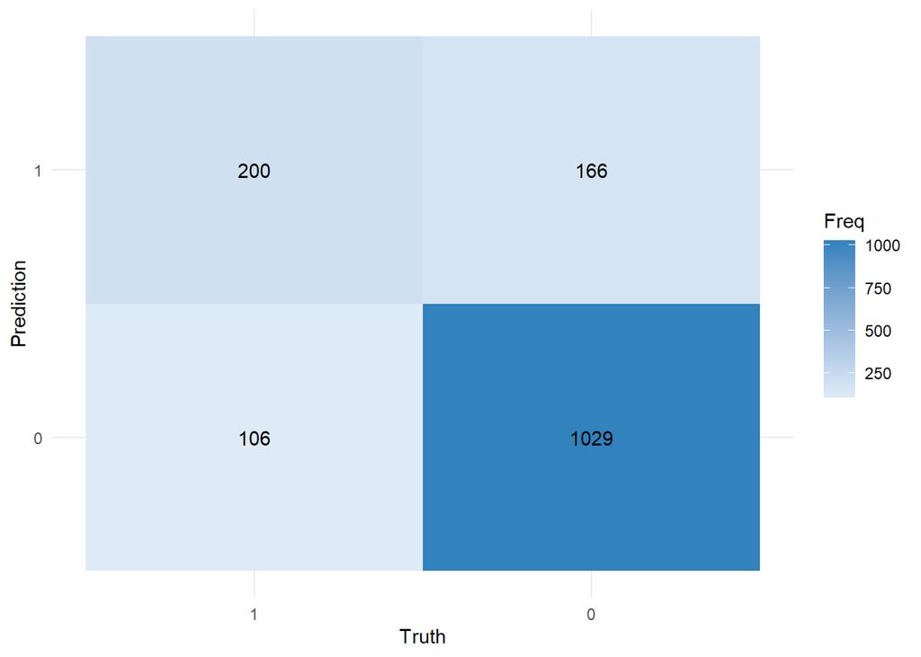

- TP (True Positive) = 200 Model poprawnie wykrył 200 klientów, którzy faktycznie odeszli.
- TN (True Negative) = 1029 Model poprawnie przewidział, że 1029 klientów nie odejdzie.
- FP (False Positive) = 166 → Model błędnie uznał, że 166 klientów odejdzie, choć zostali.
- FN (False Negative) = 106 Model nie wykrył odejścia 106 klientów, którzy faktycznie zrezygnowali.

Model skutecznie wykrywa odejścia, choć nadal generuje nieco fałszywych alarmów (FP = 166). Jednak liczba przeoczonych przypadków (FN) jest stosunkowo niska (106), co oznacza, że system oparty na tym modelu mógłby być realnie użyteczny w kampaniach utrzymania klienta (np. marketing retencyjny).

## **Finalna ewaluacja – model po tuningu na zbiorze testowym**

Po zakończeniu tuningu i przetrenowaniu modelu XGBoost na pełnym zbiorze `train + valid`, zastosowano go do predykcji na niezależnym zbiorze testowym.

```r
final_model_full <- fit(final_xgb_workflow, data = bind_rows(train_data, valid_data))

# predykcja na zbiorze testowym
preds_test <- predict(final_model_full, new_data = test_data) %>%
  bind_cols(test_data)

# predykcja na zbiorze treningowym (train + valid)
preds_train_valid <- predict(final_model_full, new_data = bind_rows(train_data, valid_data)) %>%
  bind_cols(bind_rows(train_data, valid_data))
```

### **Obliczenie metryk na nowym zbiorze treningowym (train+valid) i testowym**

| Model | Zbiór | Accuracy | Precision | Recall | F1-score |
| --- | --- | --- | --- | --- | --- |
| Tuning XGBoost | train+valid | 0.829 | 0.565 | 0.700 | 0.625 |
| Tuning XGBoost | test | 0.823 | 0.554 | 0.686 | 0.613 |

### **Macierz pomyłek – zbiór testowy**

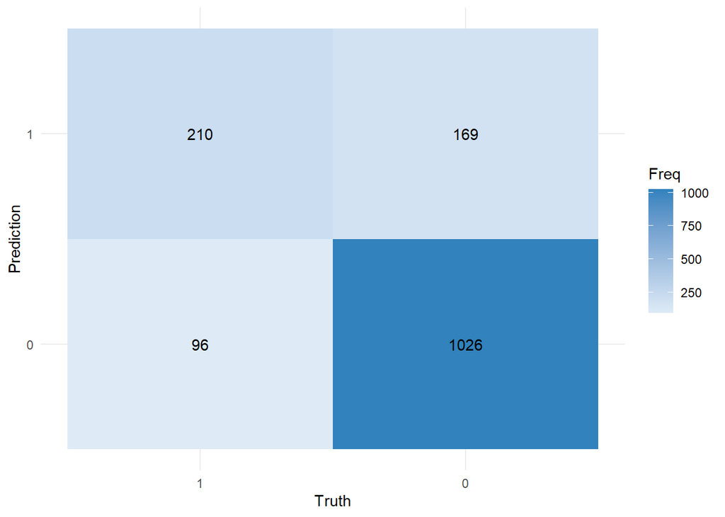

#### **Interpretacja:**

- 210 przypadków to prawidłowo wykryci klienci, którzy faktycznie odeszli (True Positives),
- 96 przypadków to klienci, którzy odeszli, ale model tego nie przewidział (False Negatives),
- 169 przypadków to fałszywe alarmy – model przewidział odejście, ale klient został (False Positives),
- 1026 przypadków to prawidłowe klasyfikacje klientów, którzy zostali (True Negatives).

## **Podsumowanie i wnioski**

Projekt miał na celu zbudowanie i ocenę modeli predykcyjnych do wykrywania odejścia klienta z banku na podstawie danych demograficznych, finansowych i behawioralnych.

Wykorzystano rzeczywisty zbiór danych **Bank Customer Churn** z platformy Kaggle. Po wstępnym oczyszczeniu danych, podzielono je na trzy niezależne zbiory (`train`, `valid`, `test`) z zachowaniem proporcji klas. Następnie przeprowadzono analizę istotności cech z wykorzystaniem **Mutual Information** oraz **metody Boruta**, wskazując finalny zestaw sześciu predyktorów:

- zmienne numeryczne: `age`, `balance`
- zmienne kategoryczne: `gender`, `active_member`, `country`, `products_number`

Analiza statystyczna wykazała, że każda z tych zmiennych istotnie różnicuje grupy klientów względem zmiennej `churn`.

W ramach dalszej analizy przetestowano pięć klasycznych modeli klasyfikacyjnych. Najlepsze wyniki – zarówno pod względem skuteczności, jak i równowagi między metrykami – uzyskał model **XGBoost**, szczególnie po zastosowaniu techniki balansowania **SMOTE**.

Przeprowadzono również **tuning hiperparametrów XGBoost** z użyciem losowego przeszukiwania przestrzeni 6 kluczowych parametrów. Choć metryki na zbiorze walidacyjnym nie poprawiły się istotnie względem modelu bazowego, tuning zapewnił **większą stabilność** wyników między zbiorem treningowym a walidacyjnym, zmniejszając ryzyko przeuczenia.

Finalny model – przetrenowany na zbiorze `train + valid` i oceniony na niezależnym zbiorze testowym – osiągnął zbliżone wyniki metryk, co potwierdza jego zdolność do generalizacji i świadczy o dobrze przeprowadzonym procesie modelowania.

Mimo tych ograniczeń, stworzony model może pełnić rolę modułu wczesnego ostrzegania, wspierającego działania retencyjne banku – np. identyfikując klientów o podwyższonym ryzyku odejścia, zanim jeszcze faktycznie zrezygnują z usług.